# Chromosomal Instability: Breakpoints

Candace Savonen for ALSF - CCDL

2020

This analysis evaluates chromosomal instability by using breakpoint SV and CNV data that was formatted by `00-setup-breakpoint_data.R` and mapping chromosomal break density. This notebook returns chromosomal break heatmaps and plots for each tumor type group in the `plots` directory.

### Usage

This notebook can be run via the command line from the top directory of the repository as follows:

```
Rscript -e "rmarkdown::render('analyses/chromosomal-instability/01-plot-chromosomal-instability.Rmd',
                              clean = TRUE)"
```

### Set Up

```r
# Set seed so heatmaps turn out the same
set.seed(2020)

# Magrittr pipe
`%>%` <- dplyr::`%>%`
```

Read in the custom functions needed for this analysis.

```r
source(file.path("util", "chr-break-calculate.R"))
source(file.path("util", "chr-break-plot.R"))
```

### Directories and Files

```r
# Path to data directory
data_dir <- file.path("..", "..", "data")
scratch_dir <- file.path("..", "..", "scratch")

# Path to output directory
plots_dir <- "plots"

# Path to tumor type plots output directory
hist_plots_dir <- file.path(plots_dir, "tumor-type")

# Create the hist_plots_dir  if it does not exist
if (!dir.exists(hist_plots_dir)) {
  dir.create(hist_plots_dir, recursive = TRUE)
}
```

### Read in data

Set up metadata

```r
# Read in the metadata
metadata <- readr::read_tsv(file.path(data_dir, "pbta-histologies.tsv"))
```

[output not shown]

Read in the intersection breaks densities TSV that was made by the 00-setup-breakpoint-data.R script.

```r
breaks_densities_df <- readr::read_tsv(
  file.path("breakpoint-data", "intersection_of_breaks_densities.tsv")
) %>%
  # Add on the short histology column from the metadata for plotting purposes
  dplyr::inner_join(metadata %>% dplyr::select(Kids_First_Biospecimen_ID, short_histology),
    by = c("samples" = "Kids_First_Biospecimen_ID")
  )
```

Load in the previously formatted breakpoint data.

```r
breaks_list <- readr::read_rds(file.path("breakpoint-data", "breaks_lists.RDS"))
```

Get a vector of the biospecimen IDs.

```r
common_samples <- unique(breaks_list$intersection_of_breaks$samples)
```

Set up uncallable regions BED.

```r
uncallable_bed <- readr::read_tsv(
  file.path(
    "..",
    "copy_number_consensus_call",
    "ref",
    "cnv_excluded_regions.bed"
  ),
  col_names = c("chrom", "start", "end")
) %>%
  # Reformat the chromosome variable to drop the "chr"
  dplyr::mutate(chrom = factor(gsub("chr", "", chrom),
    levels = c(1:22, "X", "Y")
  )) %>%
  dplyr::filter(
    !is.na(chrom),
    # Exclude the small regions
    end - start > 200000,
    # Drop sex chromosomes
    !(chrom %in% c("X", "Y", "M"))
  )
```

Set up chromosome size data. It just so happens that this BED file: `WGS.hg38.strelka2.unpadded.bed` is actually just a list of the chromosome sizes so we are using that for now.

```r
# Set up Chr sizes
chr_sizes_bed <- readr::read_tsv(file.path(data_dir, "WGS.hg38.strelka2.unpadded.bed"),
  col_names = c("chrom", "start", "end")
) %>%
  # Reformat the chromosome variable to drop the "chr"
  dplyr::mutate(chrom = factor(gsub("chr", "", chrom),
    levels = c(1:22, "X", "Y", "M")
  )) %>%
  # Remove sex chromosomes
  dplyr::filter(!(chrom %in% c("X", "Y", "M")))
# Make chromosome size named vector for Heatmap annotation
chr_sizes_vector <- chr_sizes_bed$end
names(chr_sizes_vector) <- chr_sizes_bed$chrom
```

### Plot the break densities by their histology

```r
breaks_cdf <- breaks_densities_df %>%
  # Only plot histologies groups with more than 5 samples
  dplyr::group_by(short_histology, add = TRUE) %>%
  dplyr::filter(dplyr::n() > 5) %>%
  # Calculate histology group mean
  dplyr::mutate(
    hist_mean = mean(breaks_density),
    hist_rank = rank(breaks_density) / dplyr::n()
  ) %>%
  dplyr::ungroup() %>%
  # Now we will plot these as cummulative distribution plots
  ggplot2::ggplot(ggplot2::aes(
    x = hist_rank, y = breaks_density,
    color = short_histology
  )) +
  ggplot2::geom_point() +
  # Add summary line for mean
  ggplot2::geom_hline(ggplot2::aes(yintercept = hist_mean)) +
  # Separate by histology
  ggplot2::facet_wrap(~short_histology, nrow = 2) +
  ggplot2::theme_classic() +
  ggplot2::xlab("Rank") +
  ggplot2::ylab("Chromosomal Breaks per Mb") +
  # Transform to log10 make non-log y-axis labels
  ggplot2::scale_y_continuous(trans = "log10", breaks = c(0, 1, 10, 30)) +
  ggplot2::theme(legend.position = "none") +
  # Get rid of x-axis ticks
  ggplot2::theme(
    axis.text.x = ggplot2::element_blank(),
    axis.ticks.x = ggplot2::element_blank(),
    strip.text = ggplot2::element_text(size = 4)
  )

# Save the plot to a png
ggplot2::ggsave(file.path(plots_dir, "breaks_cdf_plot.png"),
  plot = breaks_cdf, width = 17, height = 20, unit = "cm"
)
```

Print from png so rendering is smoother.

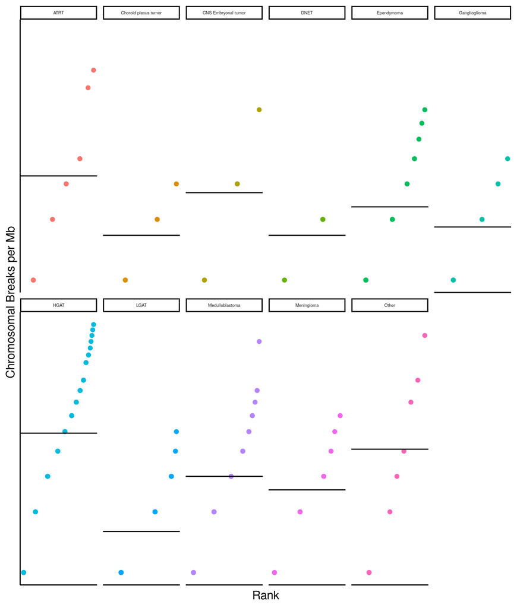

### Co-localization of breakpoints for samples

For each sample, we will bin the genome and count how many chromosome breaks occur for each bin, given the given `bin_size`.

We will run this for each sample and return a list of three `GenomicRanges` objects:  
1) `intersection_of_breaks` contains the intersection break counts for both SV and CNV break data.  
2) `cnv_breaks` contains the number of break counts for CNV.  
3) `sv_breaks` contains the number of break counts for SV.

```r
# Change here and it will change the rest
bin_size <- 1e6

# For simplicity's sake, change the name of the intersection column we want to use
breaks_list$intersection_of_breaks <- breaks_list$intersection_of_breaks %>%
  dplyr::rename(
    chrom = sv_ranges.seqnames,
    coord = sv_ranges.start
  )

# Get a big list of break densities for each sample.
sample_densities <- lapply(common_samples, function(sample_id) {
  lapply(breaks_list, function(breaks_df) {
    break_density(breaks_df,
      sample_id = sample_id,
      start_col = "coord",
      end_col = "coord",
      window_size = bin_size,
      chr_sizes_vector = chr_sizes_vector,
      unsurveyed_bed = uncallable_bed,
      perc_cutoff = .75 # What percentage of each bin needs to be callable
      # for it not to be NA
    )
  })
})

# Bring along the sample IDs
names(sample_densities) <- common_samples
```

Save to an RDS file

```r
# Save to an RDS file
readr::write_rds(
  sample_densities,
  file.path(scratch_dir, "sample_breakpoint_densities.RDS")
)
```

### Set up for making heatmaps of the breakpoints

Given the `GenomicRanges` objects for each sample, create a combined plot for each.

Make histology labeling `HeatmapAnnotation` object.

```r
# Get the histologies for the samples in this set and order them by histology
histologies <-
  data.frame(Kids_First_Biospecimen_ID = common_samples) %>%
  dplyr::inner_join(dplyr::select(metadata, Kids_First_Biospecimen_ID, short_histology)) %>%
  dplyr::mutate(short_histology = as.factor(short_histology)) %>%
  dplyr::arrange(short_histology) %>%
  tibble::column_to_rownames("Kids_First_Biospecimen_ID")
```

```
Column `Kids_First_Biospecimen_ID` joining factor and character vector, coercing into character vector
```

```r
# Create the Heatmap annotation object
hist_annot <- ComplexHeatmap::rowAnnotation(
  df = histologies,
  show_annotation_name = FALSE
)
```

Make a color function.

```r
col_fun <- circlize::colorRamp2(
  c(0, .25, .5, 1, 3),
  c("#edf8fb", "#b2e2e2", "#66c2a4", "#2ca25f", "#006d2c")
)
```

Make a function for making the heatmaps.

```r
breaks_heatmap <- function(data_name) {
  # A wrapper function for making a heatmap from the samples GenomicRanges list.
  #
  # Args:
  # data_name: a character string that matches a name in the list.

  # Returns:
  # A heatmap of the chromosomal breaks

  # Pull out the total_counts
  total_counts <- lapply(sample_densities, function(granges_list) {
    granges <- granges_list[[data_name]] # We need to tack on this uncallable regions data

    # Return only the total_counts
    sample_counts <- granges@elementMetadata@listData$total_counts

    # Name with chromosome labels
    names(sample_counts) <- S4Vectors::decode(granges@seqnames)

    return(sample_counts)
  })
  # Make into a data.frame
  total_counts_df <- dplyr::bind_rows(total_counts) %>%
    dplyr::select(rownames(histologies)) %>%
    t()

  # Extract chromosome labels
  chr_labels <- names(total_counts[[1]])

  # Add chromosome labels as column names
  colnames(total_counts_df) <- chr_labels

  # Make chromosome labeling `HeatmapAnnotation` object.
  chr_labels <- paste0("chr", as.factor(names(total_counts[[1]])))

  # Make a key for assigning alternating colors to the chromosomes
  chr_colors <- rep(c("grey", "lightblue"), length.out = length(unique(chr_labels)))
  names(chr_colors) <- unique(chr_labels)

  # Create the Heatmap annotation object
  chr_annot <- ComplexHeatmap::HeatmapAnnotation(
    df = data.frame(chr_labels), col = list(chr_labels = c(chr_colors)),
    name = "",
    show_legend = FALSE,
    show_annotation_name = FALSE
  )
  # Plot on a heatmap
  heatmap <- ComplexHeatmap::Heatmap(total_counts_df,
    col = col_fun,
    heatmap_legend_param = list(title = "Count of chr breaks"),
    cluster_columns = FALSE,
    cluster_rows = FALSE,
    show_column_names = FALSE,
    show_row_names = FALSE,
    bottom_annotation = chr_annot,
    left_annotation = hist_annot,
    na_col = "#f1f1f1"
  )
  # Return plot
  return(heatmap)
}
```

## Intersection of breaks heatmap

```r
intersection_of_heatmap <- breaks_heatmap(data_name = "intersection_of_breaks")

# Save plot as PNG
png(file.path(plots_dir, paste0("intersection_of_breaks_heatmap.png")),
  width = 1200, height = 900, units = "px"
)
intersection_of_heatmap
dev.off()
```

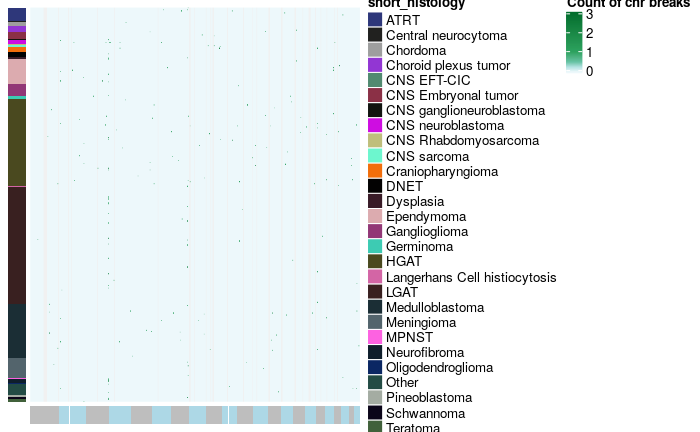

```r
# Print out here
intersection_of_heatmap
```

## CNV breaks heatmap

```r
cnv_heatmap <- breaks_heatmap(data_name = "cnv_breaks")

# Save plot as PNG
png(file.path(plots_dir, paste0("cnv_breaks_heatmap.png")),
  width = 1200, height = 900, units = "px"
)
cnv_heatmap
dev.off()
```

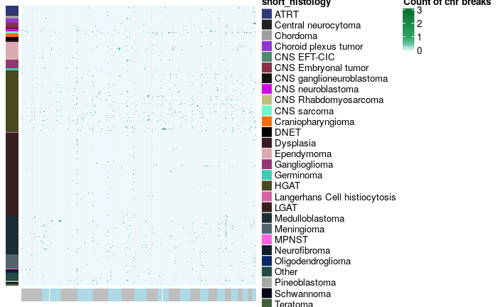

```r
# Print out here
cnv_heatmap
```

## SV breaks heatmap

```r
sv_heatmap <- breaks_heatmap(data_name = "sv_breaks")

# Save plot as PNG
png(file.path(plots_dir, paste0("sv_breaks_heatmap.png")),
  width = 1200, height = 900, units = "px"
)
sv_heatmap
dev.off()
```

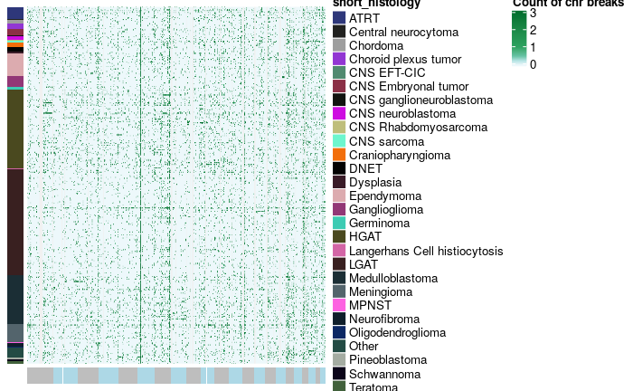

```r
# Print out here
sv_heatmap
```

### Co-localization of breakpoints for tumor-type groups

Same as was done for each sample, now we will calculate densities for each tumor-type group.

```r
# Change bin_size here and it will change the rest
bin_size <- 1e6

# Get a list of the tumor_types for which we have DNA-seq data
tumor_types <- metadata %>%
  dplyr::filter(!is.na(short_histology), experimental_strategy != "RNA-Seq") %>%
  dplyr::distinct(short_histology) %>%
  dplyr::pull(short_histology)
```

Run the density calculations for the groups.

```r
# Get a big list of break densities for each sample.
group_densities <- lapply(tumor_types, function(tumor_type) {

  # Obtain a list of sample_ids to subset by
  sample_ids <- metadata %>%
    dplyr::filter(metadata$short_histology == tumor_type) %>%
    dplyr::pull(Kids_First_Biospecimen_ID)

  # Double check these samples are in the list
  check_samples <- (sample_ids %in% common_samples)

  # If no samples, go to next
  if (sum(check_samples) > 1) {
    message(paste("Calculating breakpoint density for", tumor_type, "samples"))
    lapply(breaks_list, function(breaks_df) {
      break_density(breaks_df,
        sample_id = sample_ids,
        start_col = "coord",
        end_col = "coord",
        window_size = bin_size,
        chr_sizes_vector = chr_sizes_vector,
        unsurveyed_bed = uncallable_bed,
        perc_cutoff = .75
      )
    })
  }
})
```

```
Calculating breakpoint density for Ependymoma samples
Calculating breakpoint density for HGAT samples
Calculating breakpoint density for LGAT samples
Calculating breakpoint density for Other samples
Calculating breakpoint density for CNS sarcoma samples
Calculating breakpoint density for Schwannoma samples
Calculating breakpoint density for ATRT samples
Calculating breakpoint density for Choroid plexus tumor samples
Calculating breakpoint density for Craniopharyngioma samples
Calculating breakpoint density for DNET samples
Calculating breakpoint density for Teratoma samples
Calculating breakpoint density for Meningioma samples
Calculating breakpoint density for Neurofibroma samples
Calculating breakpoint density for Ganglioglioma samples
Calculating breakpoint density for CNS Embryonal tumor samples
Calculating breakpoint density for CNS neuroblastoma samples
Calculating breakpoint density for Chordoma samples
Calculating breakpoint density for Pineoblastoma samples
Calculating breakpoint density for Germinoma samples
Calculating breakpoint density for Dysplasia samples
Calculating breakpoint density for Oligodendroglioma samples
Calculating breakpoint density for Medulloblastoma samples
```

```r
# Bring along the tumor-type labels
names(group_densities) <- tumor_types

# Remove tumor_types data that didn't have at least two samples
group_densities <- group_densities[!sapply(group_densities, is.null)]
```

Save to an RDS file

```r
# Save to an RDS file
readr::write_rds(
  group_densities,
  file.path(scratch_dir, "histology_breakpoint_densities.RDS")
)
```

### Plot the breakpoints for each tumor-type

```
Removed 1 rows containing missing values (geom_path).Removed 1 rows containing missing values (geom_path).Removed 1 rows containing missing values (geom_path).
```

```
$Ependymoma

$HGAT

$LGAT

$Other

$`CNS sarcoma`

$Schwannoma

$ATRT

$`Choroid plexus tumor`

$Craniopharyngioma

$DNET

$Teratoma

$Meningioma

$Neurofibroma

$Ganglioglioma

$`CNS Embryonal tumor`

$`CNS neuroblastoma`

$Chordoma

$Pineoblastoma

$Germinoma

$Dysplasia

$Oligodendroglioma

$Medulloblastoma
```

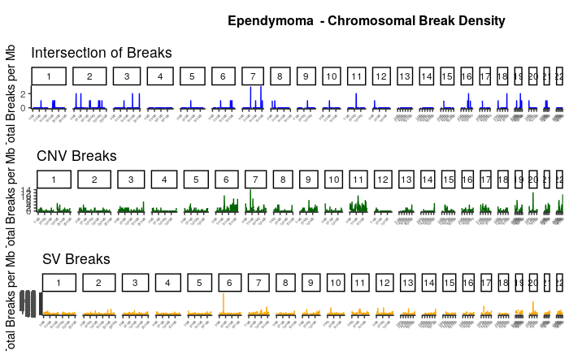

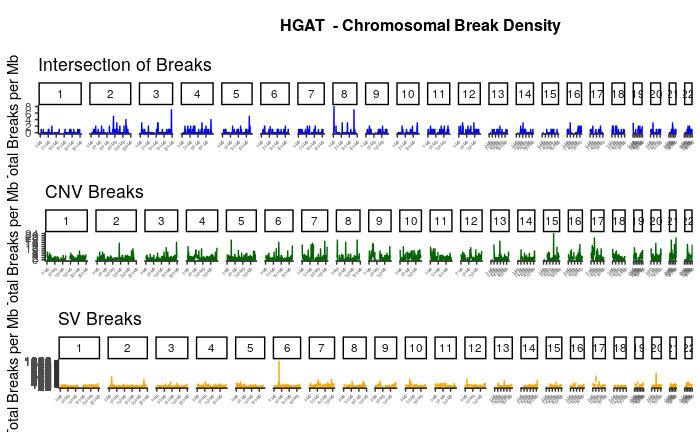

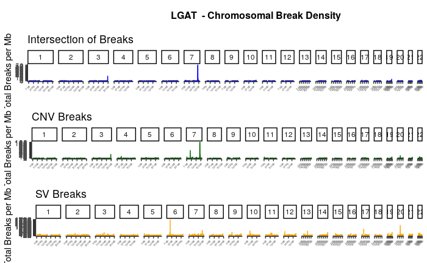

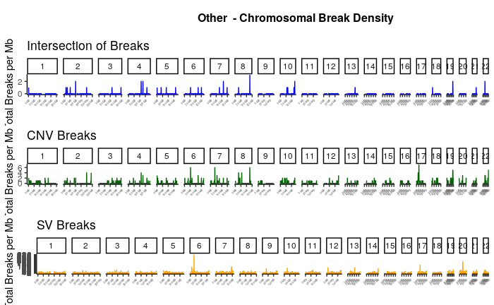

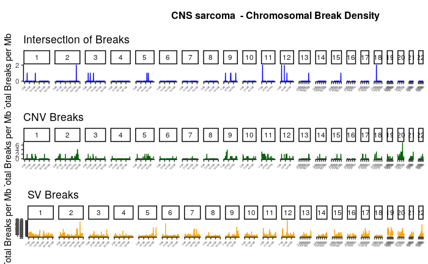

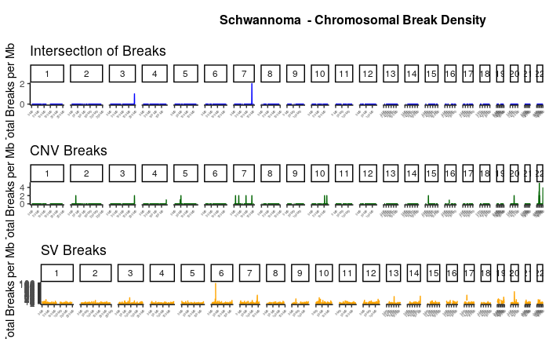

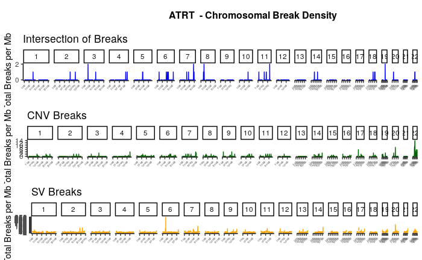

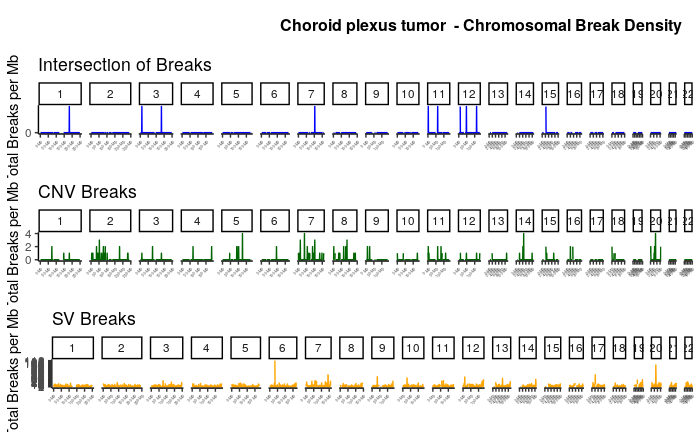

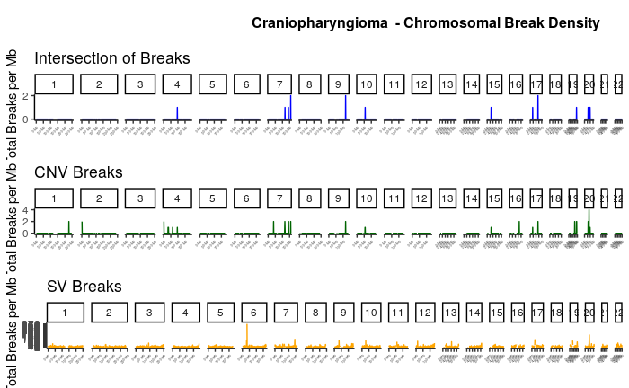

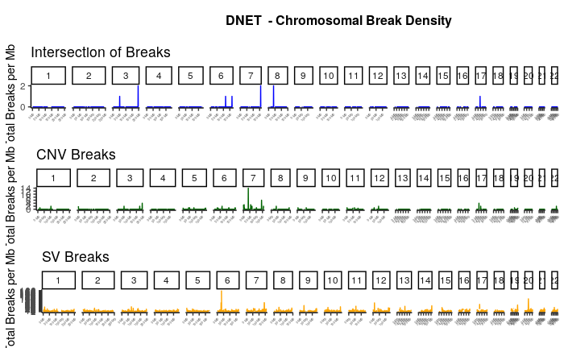

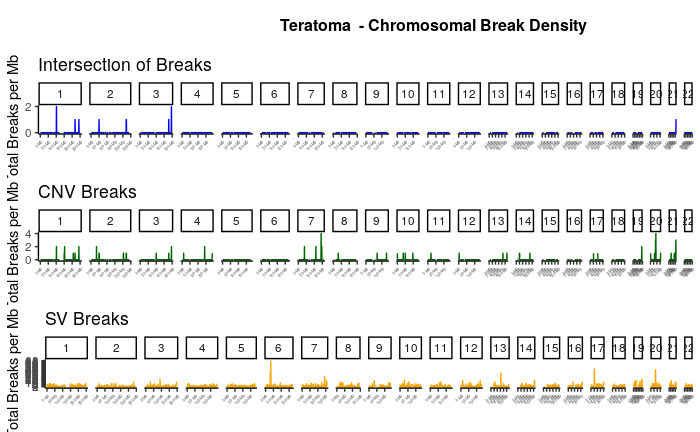

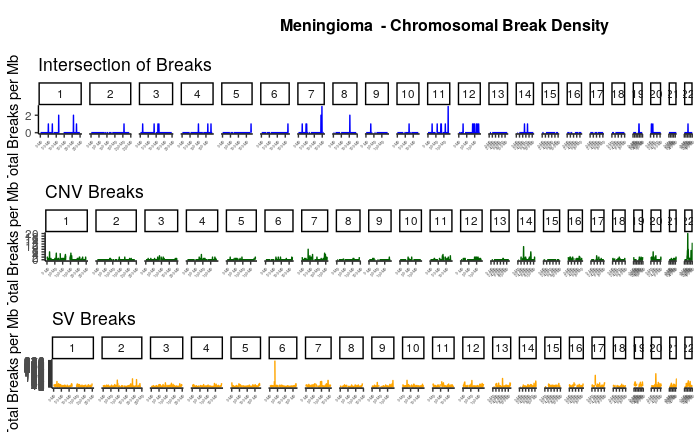

[10 more figures not shown]

```r
purrr::imap(group_densities, function(.x, name = .y) {
  # Make the combo plot
  multipanel_break_plot(
    granges_list = .x,
    plot_name = name,
    y_val = "total_counts",
    y_lab = "Total Breaks per Mb",
    plot_dir = hist_plots_dir
  )
})
```

Zip up the PNG files into one file.

```r
# Declare name of zip file
zip_file <- paste0(hist_plots_dir, ".zip")

# Remove any current zip_file of this name so we can overwrite it
if (file.exists(zip_file)) {
  file.remove(zip_file)
}
```

```
[1] TRUE
```

```r
# Zip up the plots
zip(zip_file, hist_plots_dir)
```

[output not shown]